# 01 — Setup, Data Splitting & Exploration

**Project:** Tomato Quality Semantic Segmentation — Background Bias Analysis  
**Models:** U-Net with MobileNetV2 & EfficientNet-B0 Encoders

## What this notebook does

1. Installs and imports all dependencies
2. Defines all project-wide constants and configuration
3. Loads and validates the Laboro Tomato dataset (Train split only — the original Test set is discarded)
4. Performs a **stratified deterministic split** of the training data into Train / Val / Test subsets
5. Saves the split indices to disk so every subsequent notebook uses identical splits
6. Performs comprehensive EDA: class distribution, image statistics, polygon coverage, per-split breakdowns, and sample visualizations

> **Important:** The original dataset `Test/` directory is intentionally ignored throughout the project because its annotations are corrupted. All evaluation is performed on a held-out subset carved from `Train/`.

## 1. Install Dependencies

```python
%pip install -q segmentation-models-pytorch albumentations grad-cam scikit-learn
```

## 2. Imports

```python
import os
import json
import glob
import random
import warnings
import copy
from pathlib import Path
from collections import Counter, defaultdict

import numpy as np
import pandas as pd
import matplotlib.pyplot as plt
import matplotlib.patches as mpatches
import matplotlib.gridspec as gridspec
from matplotlib.colors import LinearSegmentedColormap
import seaborn as sns

import cv2

import torch
import torch.nn as nn

import segmentation_models_pytorch as smp

warnings.filterwarnings('ignore')

os.chdir(r'C:\Personal Data\Thesis\tomato-background-bias')

# ── Global plot style ────────────────────────────────────────────────────────
plt.rcParams['figure.figsize']  = (14, 8)
plt.rcParams['figure.dpi']      = 100
plt.rcParams['axes.spines.top']    = False
plt.rcParams['axes.spines.right']  = False
sns.set_style('whitegrid')
PALETTE = ['#2196F3', '#FF5722', '#4CAF50', '#FF9800', '#9C27B0', '#00BCD4', '#795548']

print(f'PyTorch  : {torch.__version__}')
print(f'SMP      : {smp.__version__}')
DEVICE = torch.device('cuda' if torch.cuda.is_available() else 'cpu')
print(f'Device   : {DEVICE}')
if torch.cuda.is_available():
    print(f'GPU      : {torch.cuda.get_device_name(0)}')
    print(f'VRAM     : {torch.cuda.get_device_properties(0).total_memory / 1e9:.2f} GB')
```

```
PyTorch  : 2.6.0+cpu
SMP      : 0.5.0
Device   : cpu
```

## 3. Project-Wide Constants & Configuration

All constants defined here are also written to `config.py` at the end of this notebook so every subsequent notebook can simply `from config import *`.

```python
# ── Reproducibility ──────────────────────────────────────────────────────────
SEED = 42
random.seed(SEED)
np.random.seed(SEED)
torch.manual_seed(SEED)
torch.cuda.manual_seed_all(SEED)
torch.backends.cudnn.deterministic = True
torch.backends.cudnn.benchmark     = False

# ── Paths ────────────────────────────────────────────────────────────────────
# INPUT_DIR  = Path(os.environ.get('TOMATO_DATA_DIR',
#                   '/kaggle/input/datasets/sharifbek/tomato/tomato-dataset'))
# OUTPUT_DIR = Path(os.environ.get('TOMATO_OUTPUT_DIR', '/kaggle/working'))

INPUT_DIR = Path(os.environ.get('TOMATO_DATA_DIR',
                                'data/tomato-dataset'))
OUTPUT_DIR = Path(os.environ.get('TOMATO_OUTPUT_DIR', 'outputs'))
OUTPUT_DIR.mkdir(parents=True, exist_ok=True)

TRAIN_IMG_DIR = INPUT_DIR / 'Train' / 'img'
TRAIN_ANN_DIR = INPUT_DIR / 'Train' / 'ann'
META_PATH     = INPUT_DIR / 'meta.json'

# Split index file — shared by all notebooks
SPLIT_FILE = OUTPUT_DIR / 'dataset_splits.json'

# ── Class configuration ──────────────────────────────────────────────────────
CLASS_NAMES = [
    'background',       # 0
    'b_fully_ripened',  # 1
    'b_half_ripened',   # 2
    'b_green',          # 3
    'l_fully_ripened',  # 4
    'l_half_ripened',   # 5
    'l_green',          # 6
]
NUM_CLASSES       = len(CLASS_NAMES)   # 7
CLASS_TITLE_TO_IDX = {n: i for i, n in enumerate(CLASS_NAMES) if n != 'background'}

# ── Colors (RGB) ─────────────────────────────────────────────────────────────
CLASS_COLORS = [
    (  0,   0,   0),   # background      — black
    (255,  80, 120),   # b_fully_ripened — red-pink
    ( 80, 120, 255),   # b_half_ripened  — blue
    ( 80, 255, 180),   # b_green         — mint
    (255, 140,  80),   # l_fully_ripened — orange
    (120,  80, 255),   # l_half_ripened  — purple
    ( 80, 200,  80),   # l_green         — green
]

# ── Paint priority (most common first → rarest last, so rare classes are on top) ─
PAINT_PRIORITY_NAMES = [
    'l_green',
    'b_green',
    'l_fully_ripened',
    'b_fully_ripened',
    'l_half_ripened',
    'b_half_ripened',
]
PAINT_PRIORITY         = PAINT_PRIORITY_NAMES.copy()
PAINT_PRIORITY_INDICES = [CLASS_TITLE_TO_IDX[n] for n in PAINT_PRIORITY_NAMES]

# ── Hyper-parameters ─────────────────────────────────────────────────────────
IMG_SIZE          = 512
BATCH_SIZE_TRAIN  = 8
BATCH_SIZE_VAL    = 4
BATCH_SIZE_TEST   = 4
NUM_EPOCHS        = 40
LEARNING_RATE     = 1e-4
EARLY_STOP_PATIENCE = 7
NEUTRAL_BG_COLOR  = (128, 128, 128)

# ── Split ratios ──────────────────────────────────────────────────────────────
TRAIN_RATIO = 0.70   # 70 % of all Train/ images → model training
VAL_RATIO   = 0.15   # 15 % → validation / early stopping
TEST_RATIO  = 0.15   # 15 % → final held-out test evaluation

# ── Environment settings ─────────────────────────────────────────────────────
NUM_WORKERS = 0      # Windows: 0 | Kaggle/Linux GPU: 4",
PIN_MEMORY  = False  # Windows: False | Kaggle/Linux GPU: True",

print('Configuration loaded.')
print(f'  IMG_SIZE        : {IMG_SIZE}')
print(f'  NUM_CLASSES     : {NUM_CLASSES}')
print(f'  Split ratios    : train={TRAIN_RATIO} / val={VAL_RATIO} / test={TEST_RATIO}')
print(f'  Output dir      : {OUTPUT_DIR}')
```

```
Configuration loaded.
  IMG_SIZE        : 512
  NUM_CLASSES     : 7
  Split ratios    : train=0.7 / val=0.15 / test=0.15
  Output dir      : outputs
```

## 4. Load Meta.json & Map Class IDs

```python
assert META_PATH.exists(), f'meta.json not found at {META_PATH}'

with open(META_PATH, 'r') as f:
    meta = json.load(f)

META_ID_TO_CLASS_IDX = {}
CLASS_IDX_TO_META_ID = {}

print('Classes in meta.json:')
for cls in meta.get('classes', []):
    title   = cls['title']
    meta_id = cls['id']
    if title in CLASS_TITLE_TO_IDX:
        idx = CLASS_TITLE_TO_IDX[title]
        META_ID_TO_CLASS_IDX[meta_id] = idx
        CLASS_IDX_TO_META_ID[idx]     = meta_id
        print(f'  ✅  ID {meta_id:6d}  "{title}"  →  class index {idx}')
    else:
        print(f'  ⚠️   ID {meta_id:6d}  "{title}"  →  NOT IN CLASS_NAMES')

print(f'\nTotal mappings: {len(META_ID_TO_CLASS_IDX)}')
```

```
Classes in meta.json:
  ✅  ID  20789  "b_fully_ripened"  →  class index 1
  ✅  ID  20791  "b_green"  →  class index 3
  ✅  ID  20790  "b_half_ripened"  →  class index 2
  ✅  ID  20792  "l_fully_ripened"  →  class index 4
  ✅  ID  20794  "l_green"  →  class index 6
  ✅  ID  20793  "l_half_ripened"  →  class index 5

Total mappings: 6
```

## 5. Validate Dataset Paths & Collect All Files

```python
def collect_image_annotation_pairs(img_dir, ann_dir):
    """
    Return a sorted list of (image_path, annotation_path) tuples.
    Annotation filenames follow the Supervisely pattern: <name>.jpg.json
    """
    img_dir = Path(img_dir)
    ann_dir = Path(ann_dir)

    all_imgs  = sorted(list(img_dir.glob('*.jpg')) + list(img_dir.glob('*.png')))
    img_map   = {p.stem: p for p in all_imgs}   # stem = filename without ext

    pairs   = []
    missing = []
    for ann_path in sorted(ann_dir.glob('*.json')):
        # ann_path.stem  →  e.g. 'IMG_1187.jpg'
        # strip the trailing image extension if present
        stem = ann_path.stem
        for ext in ('.jpg', '.jpeg', '.png'):
            if stem.lower().endswith(ext):
                stem = stem[: -len(ext)]
                break
        if stem in img_map:
            pairs.append((img_map[stem], ann_path))
        else:
            missing.append(ann_path.name)

    if missing:
        print(f'⚠️  {len(missing)} annotations have no matching image — skipped.')
    return pairs


# Collect only from Train/ — the original Test/ is ignored
assert TRAIN_IMG_DIR.exists(), f'Missing: {TRAIN_IMG_DIR}'
assert TRAIN_ANN_DIR.exists(), f'Missing: {TRAIN_ANN_DIR}'

all_pairs = collect_image_annotation_pairs(TRAIN_IMG_DIR, TRAIN_ANN_DIR)
print(f'Total valid image-annotation pairs from Train/ : {len(all_pairs)}')

# Quick sanity — show 5 sample pairs
print('\nSample pairs:')
for img_p, ann_p in all_pairs[:5]:
    print(f'  {img_p.name}  ←→  {ann_p.name}')
```

```
Total valid image-annotation pairs from Train/ : 643

Sample pairs:
  IMG_0984.jpg  ←→  IMG_0984.jpg.json
  IMG_0985.jpg  ←→  IMG_0985.jpg.json
  IMG_0989.jpg  ←→  IMG_0989.jpg.json
  IMG_0990.jpg  ←→  IMG_0990.jpg.json
  IMG_0994.jpg  ←→  IMG_0994.jpg.json
```

## 6. Stratified Train / Val / Test Split

We stratify by the **dominant foreground class** in each image so that rare classes (e.g. `b_fully_ripened`) are represented proportionally in every split.

```python
def get_dominant_class(ann_path):
    """Return the most-frequent foreground class index in an annotation file."""
    with open(ann_path) as f:
        ann = json.load(f)
    counts = Counter()
    for obj in ann['objects']:
        title = obj.get('classTitle', '')
        if title in CLASS_TITLE_TO_IDX:
            counts[CLASS_TITLE_TO_IDX[title]] += 1
    return counts.most_common(1)[0][0] if counts else 0


def stratified_split(pairs, train_r, val_r, seed=SEED):
    """
    Split pairs into (train, val, test) using per-dominant-class stratification.
    Returns three lists of (img_path, ann_path) tuples.
    """
    rng = random.Random(seed)

    # Group by dominant class
    groups = defaultdict(list)
    for pair in pairs:
        dom = get_dominant_class(pair[1])
        groups[dom].append(pair)

    train_set, val_set, test_set = [], [], []
    for dom_cls, grp in groups.items():
        rng.shuffle(grp)
        n       = len(grp)
        n_train = int(np.floor(train_r * n))
        n_val   = int(np.floor(val_r   * n))
        # remainder goes to test
        train_set.extend(grp[:n_train])
        val_set  .extend(grp[n_train : n_train + n_val])
        test_set .extend(grp[n_train + n_val :])

    # Final shuffle so ordering is not class-grouped
    rng.shuffle(train_set)
    rng.shuffle(val_set)
    rng.shuffle(test_set)
    return train_set, val_set, test_set


print('Computing dominant classes (this may take ~30 s on 643 files)...')
train_pairs, val_pairs, test_pairs = stratified_split(
    all_pairs, TRAIN_RATIO, VAL_RATIO
)

print(f'\nSplit result:')
print(f'  Train : {len(train_pairs):4d}  ({len(train_pairs)/len(all_pairs)*100:.1f} %)')
print(f'  Val   : {len(val_pairs):4d}  ({len(val_pairs)/len(all_pairs)*100:.1f} %)')
print(f'  Test  : {len(test_pairs):4d}  ({len(test_pairs)/len(all_pairs)*100:.1f} %)')
print(f'  Total : {len(train_pairs)+len(val_pairs)+len(test_pairs):4d}')
```

```
Computing dominant classes (this may take ~30 s on 643 files)...

Split result:
  Train :  447  (69.5 %)
  Val   :   93  (14.5 %)
  Test  :  103  (16.0 %)
  Total :  643
```

### 6.1 Persist Splits to Disk

```python
def pairs_to_json_serializable(pairs):
    return [(str(img.relative_to(INPUT_DIR)), str(ann.relative_to(INPUT_DIR))) for img, ann in pairs]

split_data = {
    'seed'        : SEED,
    'train_ratio' : TRAIN_RATIO,
    'val_ratio'   : VAL_RATIO,
    'test_ratio'  : TEST_RATIO,
    'train'       : pairs_to_json_serializable(train_pairs),
    'val'         : pairs_to_json_serializable(val_pairs),
    'test'        : pairs_to_json_serializable(test_pairs),
}

with open(SPLIT_FILE, 'w') as f:
    json.dump(split_data, f, indent=2)

print(f'Split indices saved to: {SPLIT_FILE}')
```

```
Split indices saved to: outputs\dataset_splits.json
```

## 7. Helper — Annotation Parser

```python
def parse_annotation(ann_path):
    """
    Parse a single Supervisely annotation file.
    Returns a dict with image size, object list, and per-class object counts.
    """
    with open(ann_path) as f:
        ann = json.load(f)

    h = ann['size']['height']
    w = ann['size']['width']

    class_counts = Counter()
    polygon_areas = []
    for obj in ann['objects']:
        title = obj.get('classTitle', '')
        if title in CLASS_TITLE_TO_IDX:
            class_counts[title] += 1
            pts = np.array(obj['points']['exterior'], dtype=np.float32)
            area = cv2.contourArea(pts.reshape(-1, 1, 2).astype(np.int32))
            polygon_areas.append((title, area))

    return {
        'height'        : h,
        'width'         : w,
        'n_objects'     : len(ann['objects']),
        'class_counts'  : class_counts,
        'polygon_areas' : polygon_areas,
    }


def build_stats_df(pairs, split_name):
    """Build a per-image statistics DataFrame for a list of (img, ann) pairs."""
    rows = []
    for img_p, ann_p in pairs:
        info = parse_annotation(ann_p)
        img  = cv2.imread(str(img_p))
        row  = {
            'split'     : split_name,
            'filename'  : img_p.name,
            'height'    : info['height'],
            'width'     : info['width'],
            'n_objects' : info['n_objects'],
            'img_h'     : img.shape[0] if img is not None else None,
            'img_w'     : img.shape[1] if img is not None else None,
        }
        for cls in CLASS_NAMES[1:]:
            row[f'n_{cls}'] = info['class_counts'].get(cls, 0)
        rows.append(row)
    return pd.DataFrame(rows)


print('Parsing annotations for all three splits (this takes ~1 min)...')
df_train = build_stats_df(train_pairs, 'train')
df_val   = build_stats_df(val_pairs,   'val')
df_test  = build_stats_df(test_pairs,  'test')
df_all   = pd.concat([df_train, df_val, df_test], ignore_index=True)

print(f'Rows in combined dataframe: {len(df_all)}')
df_all.head(3)
```

```
Parsing annotations for all three splits (this takes ~1 min)...
Rows in combined dataframe: 643
```

|  | split | filename | height | width | n_objects | img_h | img_w | n_b_fully_ripened | n_b_half_ripened | n_b_green | n_l_fully_ripened | n_l_half_ripened | n_l_green |
| --- | --- | --- | --- | --- | --- | --- | --- | --- | --- | --- | --- | --- | --- |
| 0 | train | IMG_20191215_112010.jpg | 4160 | 3120 | 9 | 4160 | 3120 | 0 | 0 | 0 | 4 | 3 | 2 |
| 1 | train | IMG_20191215_112317.jpg | 4160 | 3120 | 21 | 4160 | 3120 | 0 | 0 | 0 | 1 | 3 | 17 |
| 2 | train | IMG_1278.jpg | 4032 | 3024 | 5 | 4032 | 3024 | 0 | 0 | 0 | 3 | 1 | 1 |

## 8. Exploratory Data Analysis

### 8.1 Per-Split Size Summary

```python
summary = df_all.groupby('split').agg(
    images       = ('filename',  'count'),
    total_objects= ('n_objects', 'sum'),
    mean_objects = ('n_objects', 'mean'),
    min_objects  = ('n_objects', 'min'),
    max_objects  = ('n_objects', 'max'),
).reindex(['train', 'val', 'test'])
summary['mean_objects'] = summary['mean_objects'].round(1)
print('=== Per-Split Summary ===')
print(summary.to_string())
```

```
=== Per-Split Summary ===
       images  total_objects  mean_objects  min_objects  max_objects
split
train     447           5527          12.4            1           73
val        93           1016          10.9            2           49
test      103           1238          12.0            1           53
```

### 8.2 Object Count per Class — Full Dataset

```python
cls_cols = [f'n_{c}' for c in CLASS_NAMES[1:]]
cls_totals_train = df_train[cls_cols].sum()
cls_totals_val   = df_val  [cls_cols].sum()
cls_totals_test  = df_test [cls_cols].sum()

class_count_df = pd.DataFrame({
    'Class'      : CLASS_NAMES[1:],
    'Train'      : cls_totals_train.values,
    'Val'        : cls_totals_val.values,
    'Test'       : cls_totals_test.values,
})
class_count_df['Total']   = class_count_df[['Train','Val','Test']].sum(axis=1)
class_count_df['Train %'] = (class_count_df['Train'] / class_count_df['Train'].sum() * 100).round(1)
class_count_df['Val %']   = (class_count_df['Val']   / class_count_df['Val'].sum()   * 100).round(1)
class_count_df['Test %']  = (class_count_df['Test']  / class_count_df['Test'].sum()  * 100).round(1)

print('=== Object Counts per Class ===')
print(class_count_df.to_string(index=False))
```

```
=== Object Counts per Class ===
          Class  Train  Val  Test  Total  Train %  Val %  Test %
b_fully_ripened    231   55    62    348      4.2    5.4     5.0
 b_half_ripened    368   76    76    520      6.7    7.5     6.1
        b_green   1032  204   231   1467     18.7   20.1    18.7
l_fully_ripened    681  130   171    982     12.3   12.8    13.8
 l_half_ripened    582   99   116    797     10.5    9.7     9.4
        l_green   2633  452   582   3667     47.6   44.5    47.0
```

### 8.3 Class Distribution Bar Chart

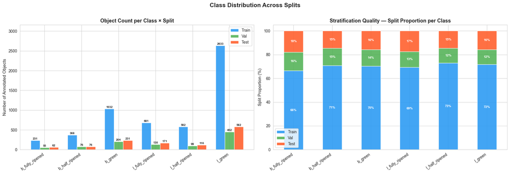

```
Saved: eda_class_distribution.png
```

```python
fig, axes = plt.subplots(1, 2, figsize=(18, 6))

# --- Grouped bar chart: object counts per class per split ---
x     = np.arange(len(CLASS_NAMES[1:]))
width = 0.25
colors = ['#2196F3', '#4CAF50', '#FF5722']

for i, (split, col) in enumerate(zip(['Train','Val','Test'], colors)):
    vals = class_count_df[split].values
    bars = axes[0].bar(x + (i - 1) * width, vals, width,
                       label=split, color=col, alpha=0.85, edgecolor='white')
    for bar, v in zip(bars, vals):
        if v > 0:
            axes[0].text(bar.get_x() + bar.get_width() / 2, bar.get_height() + 8,
                         str(int(v)), ha='center', va='bottom', fontsize=7.5,
                         fontweight='bold')

axes[0].set_xticks(x)
axes[0].set_xticklabels(CLASS_NAMES[1:], rotation=35, ha='right', fontsize=10)
axes[0].set_ylabel('Number of Annotated Objects', fontsize=11)
axes[0].set_title('Object Count per Class × Split', fontsize=13, fontweight='bold')
axes[0].legend(fontsize=10)
axes[0].set_ylim(0, class_count_df['Train'].max() * 1.2)

# --- Stacked proportion bar chart ---
class_totals = class_count_df.set_index('Class')[['Train','Val','Test']]
proportions  = class_totals.div(class_totals.sum(axis=1), axis=0) * 100

bottom = np.zeros(len(CLASS_NAMES[1:]))
for i, (split, col) in enumerate(zip(['Train','Val','Test'], colors)):
    vals = proportions[split].values
    axes[1].bar(x, vals, width=0.5, bottom=bottom, label=split,
                color=col, alpha=0.85, edgecolor='white')
    for j, (v, b) in enumerate(zip(vals, bottom)):
        if v > 3:
            axes[1].text(x[j], b + v / 2, f'{v:.0f}%',
                         ha='center', va='center', fontsize=8, color='white',
                         fontweight='bold')
    bottom += vals

axes[1].set_xticks(x)
axes[1].set_xticklabels(CLASS_NAMES[1:], rotation=35, ha='right', fontsize=10)
axes[1].set_ylabel('Split Proportion (%)', fontsize=11)
axes[1].set_title('Stratification Quality — Split Proportion per Class', fontsize=13, fontweight='bold')
axes[1].legend(fontsize=10)

plt.suptitle('Class Distribution Across Splits', fontsize=15, fontweight='bold', y=1.01)
plt.tight_layout()
plt.savefig(OUTPUT_DIR / 'eda_class_distribution.png', dpi=150, bbox_inches='tight')
plt.show()
print('Saved: eda_class_distribution.png')
```

### 8.4 Objects-per-Image Distribution

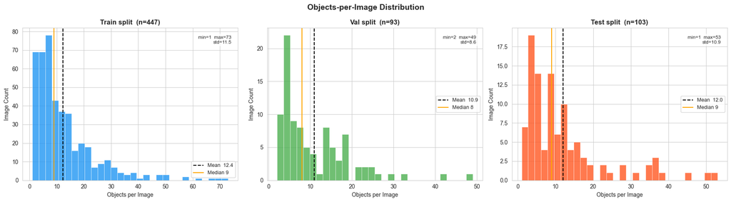

```
Saved: eda_objects_per_image.png
```

```python
fig, axes = plt.subplots(1, 3, figsize=(18, 5))
split_map = {'train': (df_train, '#2196F3'), 'val': (df_val, '#4CAF50'), 'test': (df_test, '#FF5722')}

for ax, (split, (df_s, col)) in zip(axes, split_map.items()):
    data = df_s['n_objects']
    ax.hist(data, bins=30, color=col, alpha=0.8, edgecolor='white', linewidth=0.5)
    ax.axvline(data.mean(),   color='black',  linestyle='--', linewidth=1.5, label=f'Mean  {data.mean():.1f}')
    ax.axvline(data.median(), color='orange', linestyle='-',  linewidth=1.5, label=f'Median {data.median():.0f}')
    ax.set_title(f'{split.capitalize()} split  (n={len(df_s)})', fontsize=12, fontweight='bold')
    ax.set_xlabel('Objects per Image', fontsize=10)
    ax.set_ylabel('Image Count', fontsize=10)
    ax.legend(fontsize=9)
    # Add stats box
    stats_txt = (f'min={data.min()}  max={data.max()}\n'
                 f'std={data.std():.1f}')
    ax.text(0.97, 0.95, stats_txt, transform=ax.transAxes,
            ha='right', va='top', fontsize=8.5,
            bbox=dict(boxstyle='round,pad=0.3', facecolor='white', alpha=0.7))

plt.suptitle('Objects-per-Image Distribution', fontsize=14, fontweight='bold')
plt.tight_layout()
plt.savefig(OUTPUT_DIR / 'eda_objects_per_image.png', dpi=150, bbox_inches='tight')
plt.show()
print('Saved: eda_objects_per_image.png')
```

### 8.5 Image Resolution Distribution

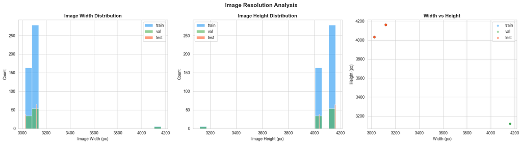

```
Saved: eda_image_resolution.png
```

```python
fig, axes = plt.subplots(1, 3, figsize=(18, 5))

# (a) Width distribution
for split, (df_s, col) in split_map.items():
    axes[0].hist(df_s['img_w'].dropna(), bins=20, alpha=0.6, color=col, label=split, edgecolor='white')
axes[0].set_xlabel('Image Width (px)', fontsize=10)
axes[0].set_ylabel('Count', fontsize=10)
axes[0].set_title('Image Width Distribution', fontsize=12, fontweight='bold')
axes[0].legend()

# (b) Height distribution
for split, (df_s, col) in split_map.items():
    axes[1].hist(df_s['img_h'].dropna(), bins=20, alpha=0.6, color=col, label=split, edgecolor='white')
axes[1].set_xlabel('Image Height (px)', fontsize=10)
axes[1].set_ylabel('Count', fontsize=10)
axes[1].set_title('Image Height Distribution', fontsize=12, fontweight='bold')
axes[1].legend()

# (c) Scatter: width vs height (colored by split)
for split, (df_s, col) in split_map.items():
    axes[2].scatter(df_s['img_w'], df_s['img_h'], alpha=0.4, color=col, s=18, label=split)
axes[2].set_xlabel('Width (px)', fontsize=10)
axes[2].set_ylabel('Height (px)', fontsize=10)
axes[2].set_title('Width vs Height', fontsize=12, fontweight='bold')
axes[2].legend()

plt.suptitle('Image Resolution Analysis', fontsize=14, fontweight='bold')
plt.tight_layout()
plt.savefig(OUTPUT_DIR / 'eda_image_resolution.png', dpi=150, bbox_inches='tight')
plt.show()
print('Saved: eda_image_resolution.png')
```

### 8.6 Polygon Area Analysis

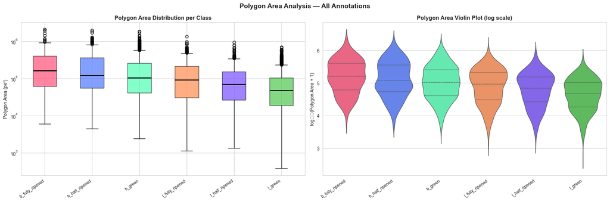

```
Saved: eda_polygon_areas.png
```

```python
# Collect per-class polygon areas from ALL pairs
area_records = []
for img_p, ann_p in all_pairs:
    info = parse_annotation(ann_p)
    for cls_name, area in info['polygon_areas']:
        area_records.append({'class': cls_name, 'area': area})

area_df = pd.DataFrame(area_records)

fig, axes = plt.subplots(1, 2, figsize=(18, 6))

# (a) Box plot of polygon areas per class
order = CLASS_NAMES[1:]
data_by_class = [area_df[area_df['class'] == cls]['area'].values for cls in order]
bp = axes[0].boxplot(data_by_class, labels=order, patch_artist=True, notch=False,
                     medianprops=dict(color='black', linewidth=2))
for patch, color in zip(bp['boxes'], [np.array(CLASS_COLORS[i+1])/255 for i in range(6)]):
    patch.set_facecolor(color)
    patch.set_alpha(0.7)
axes[0].set_xticklabels(order, rotation=35, ha='right', fontsize=9)
axes[0].set_ylabel('Polygon Area (px²)', fontsize=10)
axes[0].set_title('Polygon Area Distribution per Class', fontsize=12, fontweight='bold')
axes[0].set_yscale('log')

# (b) Violin plot (log scale)
area_plot_df = area_df[area_df['area'] > 0].copy()
area_plot_df['log_area'] = np.log10(area_plot_df['area'] + 1)
class_order_violin = sorted(area_plot_df['class'].unique(),
                             key=lambda c: CLASS_TITLE_TO_IDX[c])
violin_palette = {cls: np.array(CLASS_COLORS[CLASS_TITLE_TO_IDX[cls]])/255
                  for cls in class_order_violin}
sns.violinplot(data=area_plot_df, x='class', y='log_area',
               order=class_order_violin,
               palette={cls: tuple(c) for cls, c in violin_palette.items()},
               ax=axes[1], inner='quartile', linewidth=1)
axes[1].set_xticklabels(class_order_violin, rotation=35, ha='right', fontsize=9)
axes[1].set_ylabel('log₁₀(Polygon Area + 1)', fontsize=10)
axes[1].set_xlabel('')
axes[1].set_title('Polygon Area Violin Plot (log scale)', fontsize=12, fontweight='bold')

plt.suptitle('Polygon Area Analysis — All Annotations', fontsize=14, fontweight='bold')
plt.tight_layout()
plt.savefig(OUTPUT_DIR / 'eda_polygon_areas.png', dpi=150, bbox_inches='tight')
plt.show()
print('Saved: eda_polygon_areas.png')
```

### 8.7 Per-Class Object Count Correlation Heatmap

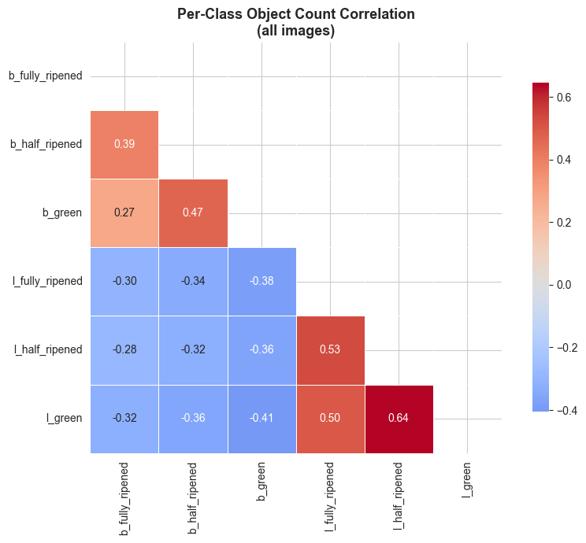

```
Saved: eda_class_correlation.png
```

```python
corr = df_all[cls_cols].rename(columns={f'n_{c}': c for c in CLASS_NAMES[1:]}).corr()

fig, ax = plt.subplots(figsize=(9, 7))
mask = np.triu(np.ones_like(corr, dtype=bool))
sns.heatmap(corr, mask=mask, annot=True, fmt='.2f', cmap='coolwarm',
            center=0, linewidths=0.5, square=True, ax=ax,
            cbar_kws={'shrink': 0.8})
ax.set_title('Per-Class Object Count Correlation\n(all images)', fontsize=13, fontweight='bold')
plt.tight_layout()
plt.savefig(OUTPUT_DIR / 'eda_class_correlation.png', dpi=150, bbox_inches='tight')
plt.show()
print('Saved: eda_class_correlation.png')
```

### 8.8 Dominant-Class Distribution per Split (Stratification Verification)

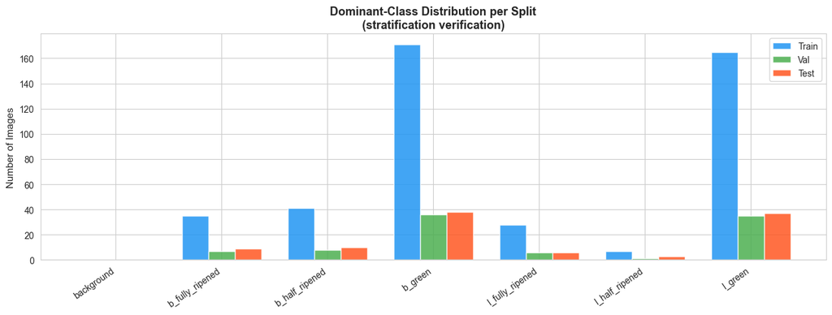

```
Saved: eda_dominant_class_split.png
```

```python
def dominant_class_counts(pairs):
    counts = Counter()
    for _, ann_p in pairs:
        dom = get_dominant_class(ann_p)
        counts[CLASS_NAMES[dom]] += 1
    return counts

dom_train = dominant_class_counts(train_pairs)
dom_val   = dominant_class_counts(val_pairs)
dom_test  = dominant_class_counts(test_pairs)

dom_df = pd.DataFrame({
    'Class' : CLASS_NAMES,
    'Train' : [dom_train.get(c, 0) for c in CLASS_NAMES],
    'Val'   : [dom_val  .get(c, 0) for c in CLASS_NAMES],
    'Test'  : [dom_test .get(c, 0) for c in CLASS_NAMES],
})

fig, ax = plt.subplots(figsize=(13, 5))
x     = np.arange(len(CLASS_NAMES))
width = 0.25
for i, (split, col) in enumerate(zip(['Train','Val','Test'], colors)):
    ax.bar(x + (i - 1) * width, dom_df[split], width,
           label=split, color=col, alpha=0.85, edgecolor='white')
ax.set_xticks(x)
ax.set_xticklabels(CLASS_NAMES, rotation=35, ha='right', fontsize=10)
ax.set_ylabel('Number of Images', fontsize=11)
ax.set_title('Dominant-Class Distribution per Split\n(stratification verification)',
             fontsize=13, fontweight='bold')
ax.legend(fontsize=10)
plt.tight_layout()
plt.savefig(OUTPUT_DIR / 'eda_dominant_class_split.png', dpi=150, bbox_inches='tight')
plt.show()
print('Saved: eda_dominant_class_split.png')
```

### 8.9 RGB Channel Statistics

```python
def compute_rgb_stats(pairs, n_sample=80):
    """Compute per-channel mean/std from a random sample of images."""
    rng = random.Random(SEED)
    sample = rng.sample(pairs, min(n_sample, len(pairs)))
    means, stds = [], []
    for img_p, _ in sample:
        img = cv2.imread(str(img_p))
        if img is None:
            continue
        img = cv2.cvtColor(img, cv2.COLOR_BGR2RGB).astype(np.float32) / 255.0
        means.append(img.reshape(-1, 3).mean(axis=0))
        stds .append(img.reshape(-1, 3).std (axis=0))
    return np.array(means), np.array(stds)

means_tr, stds_tr = compute_rgb_stats(train_pairs)
means_va, stds_va = compute_rgb_stats(val_pairs)
means_te, stds_te = compute_rgb_stats(test_pairs)

channels = ['R', 'G', 'B']
ch_colors = ['#F44336', '#4CAF50', '#2196F3']

fig, axes = plt.subplots(2, 3, figsize=(18, 9))

for col_idx, (ch, ch_col) in enumerate(zip(channels, ch_colors)):
    for row_idx, (label, means, stds) in enumerate([
        ('Mean', [means_tr[:, col_idx], means_va[:, col_idx], means_te[:, col_idx]], None),
        ('Std',  [stds_tr [:, col_idx], stds_va [:, col_idx], stds_te [:, col_idx]], None),
    ]):
        ax = axes[row_idx][col_idx]
        for split_vals, split_name, split_col in zip(
            means,
            ['Train', 'Val', 'Test'],
            ['#2196F3', '#4CAF50', '#FF5722']
        ):
            ax.hist(split_vals, bins=20, alpha=0.6, color=split_col,
                    label=split_name, edgecolor='white')
        ax.set_title(f'Channel {ch} — {label}', fontsize=11, fontweight='bold')
        ax.set_xlabel('Value', fontsize=9)
        ax.set_ylabel('Count', fontsize=9)
        if row_idx == 0 and col_idx == 0:
            ax.legend(fontsize=8)

plt.suptitle('RGB Channel Statistics Across Splits', fontsize=14, fontweight='bold')
plt.tight_layout()
plt.savefig(OUTPUT_DIR / 'eda_rgb_stats.png', dpi=150, bbox_inches='tight')
plt.show()

# Print ImageNet-style normalization stats
print('\nDataset-wide channel statistics (for normalization):')
all_means = np.vstack([means_tr, means_va, means_te])
all_stds  = np.vstack([stds_tr,  stds_va,  stds_te])
print(f'  Mean : R={all_means[:,0].mean():.4f}  G={all_means[:,1].mean():.4f}  B={all_means[:,2].mean():.4f}')
print(f'  Std  : R={all_stds[:,0].mean():.4f}   G={all_stds[:,1].mean():.4f}   B={all_stds[:,2].mean():.4f}')
print('  (ImageNet defaults: mean=[0.485, 0.456, 0.406], std=[0.229, 0.224, 0.225])')
```

[output not shown]

### 8.10 Sample Images with Polygon Annotations Overlaid

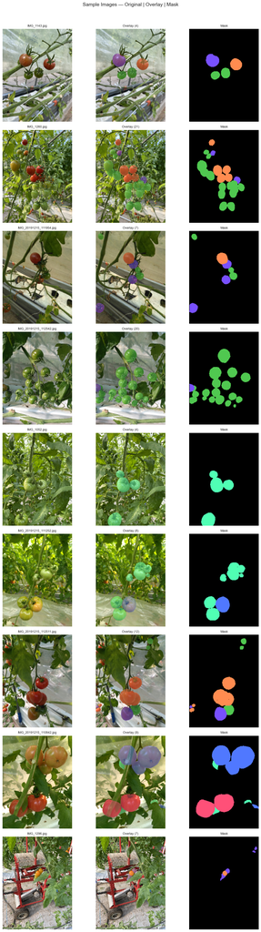

```
Saved: eda_sample_images.png
```

```python
def draw_polygons_on_image(img_bgr, ann_path, alpha=0.45):
    """Overlay filled polygons on a BGR image; return BGR result."""
    with open(ann_path) as f:
        ann = json.load(f)
    overlay = img_bgr.copy()
    objects_by_class = defaultdict(list)
    for obj in ann['objects']:
        title = obj.get('classTitle', '')
        if title in CLASS_TITLE_TO_IDX:
            objects_by_class[CLASS_TITLE_TO_IDX[title]].append(obj)
    for cls_idx in PAINT_PRIORITY_INDICES:
        color_bgr = CLASS_COLORS[cls_idx][::-1]
        for obj in objects_by_class.get(cls_idx, []):
            pts = np.array(obj['points']['exterior'], dtype=np.int32)
            cv2.fillPoly(overlay, [pts], color_bgr)
    return cv2.addWeighted(overlay, alpha, img_bgr, 1 - alpha, 0)


def show_sample_grid_simple(all_pairs, n_samples=9, title='Samples'):
    """
    Shows n_samples images in a clean 3-column layout:
    Original | Overlay | Mask
    """

    sample = random.sample(all_pairs, min(n_samples, len(all_pairs)))

    fig, axes = plt.subplots(
        n_samples, 3,
        figsize=(12, 4 * n_samples)
    )

    if n_samples == 1:
        axes = np.expand_dims(axes, axis=0)

    for row, (img_p, ann_p) in enumerate(sample):
        img = cv2.imread(str(img_p))
        if img is None:
            continue

        ann_img = draw_polygons_on_image(img, ann_p)

        with open(ann_p) as f:
            ann_data = json.load(f)

        h, w = img.shape[:2]

        # Build mask
        mask = np.zeros((h, w), dtype=np.uint8)
        for cls_name in PAINT_PRIORITY:
            cls_idx = CLASS_TITLE_TO_IDX[cls_name]
            for obj in ann_data['objects']:
                if obj.get('classTitle') == cls_name:
                    pts = np.array(obj['points']['exterior'], dtype=np.int32)
                    cv2.fillPoly(mask, [pts], cls_idx)

        colored_mask = np.zeros((h, w, 3), dtype=np.uint8)
        for c in range(NUM_CLASSES):
            colored_mask[mask == c] = CLASS_COLORS[c]

        # Resize consistently
        display_h = 256
        display_w = int(w * (display_h / h))

        img_rgb = cv2.cvtColor(cv2.resize(
            img,      (display_w, display_h)), cv2.COLOR_BGR2RGB)
        ann_rgb = cv2.cvtColor(cv2.resize(
            ann_img,  (display_w, display_h)), cv2.COLOR_BGR2RGB)
        mask_rgb = cv2.resize(
            colored_mask, (display_w, display_h), interpolation=cv2.INTER_NEAREST)

        titles = [
            f'{img_p.name}',
            f'Overlay ({len(ann_data["objects"])})',
            'Mask'
        ]

        for col in range(3):
            axes[row, col].imshow([img_rgb, ann_rgb, mask_rgb][col])
            axes[row, col].set_title(titles[col], fontsize=9)
            axes[row, col].axis('off')

    plt.tight_layout()
    fig.suptitle(title, fontsize=14, y=1.02)

    return fig

rng_sample = random.Random(SEED + 1)
all_pairs = train_pairs + val_pairs + test_pairs

fig = show_sample_grid_simple(
    all_pairs,
    n_samples=9,
    title='Sample Images — Original | Overlay | Mask'
)
fig.savefig(OUTPUT_DIR / 'eda_sample_images.png', dpi=150, bbox_inches='tight')
plt.show()
print('Saved: eda_sample_images.png')
```

### 8.11 Pixel-Level Class Balance (from a sample)

```
Estimating pixel-level class balance (100-image sample)...

=== Pixel-Level Class Balance ===
          Class   Pixels  Frequency%  Inv-Weight
     background 22854861       87.18       0.023
b_fully_ripened   289533        1.10       1.812
 b_half_ripened   447759        1.71       1.172
        b_green   724959        2.77       0.724
l_fully_ripened   552138        2.11       0.950
 l_half_ripened   287746        1.10       1.823
        l_green  1057404        4.03       0.496
```

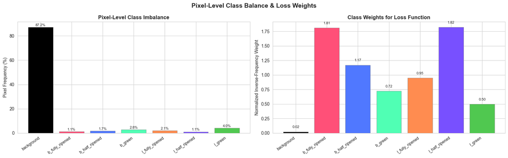

```
Saved: eda_pixel_balance.png
```

```python
def compute_pixel_balance(pairs, n_sample=100, img_size=512):
    """
    Estimate pixel-level class frequencies from a random sample.
    Returns per-class pixel counts and frequencies.
    """
    rng  = random.Random(SEED)
    sample = rng.sample(pairs, min(n_sample, len(pairs)))
    pixel_counts = np.zeros(NUM_CLASSES, dtype=np.int64)

    for img_p, ann_p in sample:
        with open(ann_p) as f:
            ann = json.load(f)
        h = ann['size']['height']
        w = ann['size']['width']
        mask = np.zeros((h, w), dtype=np.uint8)
        for cls_name in PAINT_PRIORITY:
            cls_idx = CLASS_TITLE_TO_IDX[cls_name]
            for obj in ann['objects']:
                if obj.get('classTitle') == cls_name:
                    pts = np.array(obj['points']['exterior'], dtype=np.int32)
                    cv2.fillPoly(mask, [pts], cls_idx)
        mask_resized = cv2.resize(mask, (img_size, img_size),
                                  interpolation=cv2.INTER_NEAREST)
        for c in range(NUM_CLASSES):
            pixel_counts[c] += int((mask_resized == c).sum())

    freq = pixel_counts / pixel_counts.sum()
    return pixel_counts, freq


print('Estimating pixel-level class balance (100-image sample)...')
px_counts, px_freq = compute_pixel_balance(all_pairs, n_sample=100)

# Compute inverse-frequency weights (as used in training)
freq_safe    = np.maximum(px_freq, 1e-8)
inv_weights  = 1.0 / freq_safe
norm_weights = inv_weights / inv_weights.sum() * NUM_CLASSES

pixel_df = pd.DataFrame({
    'Class'      : CLASS_NAMES,
    'Pixels'     : px_counts,
    'Frequency%' : (px_freq * 100).round(2),
    'Inv-Weight' : norm_weights.round(3),
})
print('\n=== Pixel-Level Class Balance ===')
print(pixel_df.to_string(index=False))

# Plot
fig, axes = plt.subplots(1, 2, figsize=(16, 5))

bar_cols = [np.array(CLASS_COLORS[i])/255. for i in range(NUM_CLASSES)]
axes[0].bar(CLASS_NAMES, px_freq * 100, color=bar_cols, edgecolor='grey', linewidth=0.5)
axes[0].set_xticklabels(CLASS_NAMES, rotation=35, ha='right', fontsize=9)
axes[0].set_ylabel('Pixel Frequency (%)', fontsize=10)
axes[0].set_title('Pixel-Level Class Imbalance', fontsize=12, fontweight='bold')
for i, v in enumerate(px_freq * 100):
    axes[0].text(i, v + 0.3, f'{v:.1f}%', ha='center', va='bottom', fontsize=8)

axes[1].bar(CLASS_NAMES, norm_weights, color=bar_cols, edgecolor='grey', linewidth=0.5)
axes[1].set_xticklabels(CLASS_NAMES, rotation=35, ha='right', fontsize=9)
axes[1].set_ylabel('Normalized Inverse-Frequency Weight', fontsize=10)
axes[1].set_title('Class Weights for Loss Function', fontsize=12, fontweight='bold')
for i, v in enumerate(norm_weights):
    axes[1].text(i, v + 0.05, f'{v:.2f}', ha='center', va='bottom', fontsize=8)

plt.suptitle('Pixel-Level Class Balance & Loss Weights', fontsize=14, fontweight='bold')
plt.tight_layout()
plt.savefig(OUTPUT_DIR / 'eda_pixel_balance.png', dpi=150, bbox_inches='tight')
plt.show()
print('Saved: eda_pixel_balance.png')
```

### 8.12 Mask Coverage (Foreground vs Background Ratio)

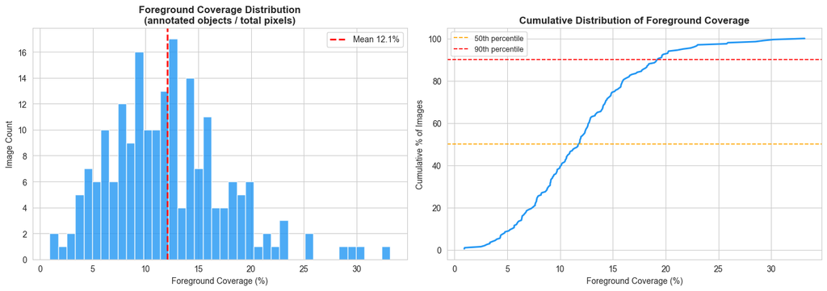

```
Mean FG coverage : 12.1%
Median FG coverage: 11.8%
Saved: eda_fg_coverage.png
```

```python
def compute_fg_coverage(pairs, n_sample=120):
    """Compute foreground pixel coverage ratio for each image in a sample."""
    rng    = random.Random(SEED + 99)
    sample = rng.sample(pairs, min(n_sample, len(pairs)))
    ratios = []
    for img_p, ann_p in sample:
        with open(ann_p) as f:
            ann = json.load(f)
        h = ann['size']['height']
        w = ann['size']['width']
        fg = np.zeros((h, w), dtype=np.uint8)
        for obj in ann['objects']:
            if obj.get('classTitle','') in CLASS_TITLE_TO_IDX:
                pts = np.array(obj['points']['exterior'], dtype=np.int32)
                cv2.fillPoly(fg, [pts], 1)
        ratios.append(fg.sum() / (h * w))
    return np.array(ratios)

cov_all = compute_fg_coverage(all_pairs, n_sample=200)

fig, axes = plt.subplots(1, 2, figsize=(14, 5))

axes[0].hist(cov_all * 100, bins=40, color='#2196F3', alpha=0.8, edgecolor='white')
axes[0].axvline(np.mean(cov_all) * 100, color='red', linestyle='--',
                linewidth=2, label=f'Mean {np.mean(cov_all)*100:.1f}%')
axes[0].set_xlabel('Foreground Coverage (%)', fontsize=10)
axes[0].set_ylabel('Image Count', fontsize=10)
axes[0].set_title('Foreground Coverage Distribution\n(annotated objects / total pixels)',
                   fontsize=12, fontweight='bold')
axes[0].legend(fontsize=10)

# Cumulative
sorted_cov = np.sort(cov_all)
cdf = np.arange(1, len(sorted_cov)+1) / len(sorted_cov)
axes[1].plot(sorted_cov * 100, cdf * 100, color='#2196F3', linewidth=2)
axes[1].axhline(50, color='orange', linestyle='--', linewidth=1.2, label='50th percentile')
axes[1].axhline(90, color='red',    linestyle='--', linewidth=1.2, label='90th percentile')
axes[1].set_xlabel('Foreground Coverage (%)', fontsize=10)
axes[1].set_ylabel('Cumulative % of Images', fontsize=10)
axes[1].set_title('Cumulative Distribution of Foreground Coverage',
                   fontsize=12, fontweight='bold')
axes[1].legend(fontsize=9)

plt.tight_layout()
plt.savefig(OUTPUT_DIR / 'eda_fg_coverage.png', dpi=150, bbox_inches='tight')
plt.show()
print(f'Mean FG coverage : {np.mean(cov_all)*100:.1f}%')
print(f'Median FG coverage: {np.median(cov_all)*100:.1f}%')
print('Saved: eda_fg_coverage.png')
```

### 8.13 Summary Dashboard — All Key Metrics in One Figure

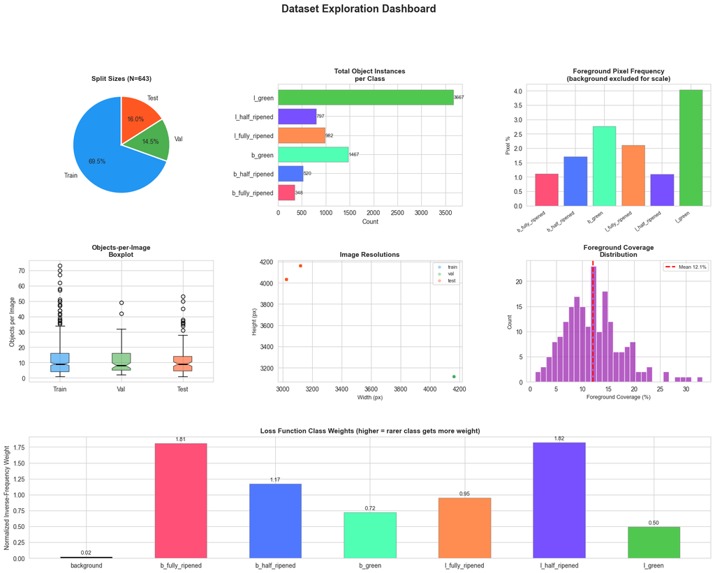

```
Saved: eda_dashboard.png
```

```python
fig = plt.figure(figsize=(20, 14))
gs  = gridspec.GridSpec(3, 3, figure=fig, hspace=0.45, wspace=0.35)

# ── (0,0) Split sizes ──────────────────────────────────────────────────────
ax00 = fig.add_subplot(gs[0, 0])
split_sizes  = [len(train_pairs), len(val_pairs), len(test_pairs)]
split_labels = ['Train', 'Val', 'Test']
wedges, texts, autotexts = ax00.pie(
    split_sizes, labels=split_labels,
    colors=['#2196F3', '#4CAF50', '#FF5722'],
    autopct='%1.1f%%', startangle=90,
    wedgeprops=dict(edgecolor='white', linewidth=2)
)
for at in autotexts:
    at.set_fontsize(10)
ax00.set_title(f'Split Sizes (N={len(all_pairs)})', fontsize=11, fontweight='bold')

# ── (0,1) Total objects per class ─────────────────────────────────────────
ax01 = fig.add_subplot(gs[0, 1])
cls_total_all = class_count_df.set_index('Class')['Total']
ax01.barh(cls_total_all.index, cls_total_all.values,
          color=[np.array(CLASS_COLORS[i+1])/255. for i in range(6)],
          edgecolor='grey', linewidth=0.5)
for i, v in enumerate(cls_total_all.values):
    ax01.text(v + 10, i, str(int(v)), va='center', fontsize=8)
ax01.set_title('Total Object Instances\nper Class', fontsize=11, fontweight='bold')
ax01.set_xlabel('Count')

# ── (0,2) Pixel frequency ─────────────────────────────────────────────────
ax02 = fig.add_subplot(gs[0, 2])
fg_freq = px_freq[1:]   # skip background for readability
fg_names = CLASS_NAMES[1:]
ax02.bar(fg_names, fg_freq * 100,
         color=[np.array(CLASS_COLORS[i+1])/255. for i in range(6)],
         edgecolor='grey', linewidth=0.5)
ax02.set_xticklabels(fg_names, rotation=35, ha='right', fontsize=8)
ax02.set_ylabel('Pixel %', fontsize=9)
ax02.set_title('Foreground Pixel Frequency\n(background excluded for scale)',
               fontsize=11, fontweight='bold')

# ── (1,0) Objects per image — boxplot ─────────────────────────────────────
ax10 = fig.add_subplot(gs[1, 0])
data_bp = [df_train['n_objects'].values, df_val['n_objects'].values, df_test['n_objects'].values]
bp = ax10.boxplot(data_bp, labels=['Train','Val','Test'], patch_artist=True, notch=True,
                  medianprops=dict(color='black', linewidth=2))
for patch, col in zip(bp['boxes'], ['#2196F3','#4CAF50','#FF5722']):
    patch.set_facecolor(col); patch.set_alpha(0.6)
ax10.set_ylabel('Objects per Image')
ax10.set_title('Objects-per-Image\nBoxplot', fontsize=11, fontweight='bold')

# ── (1,1) Image resolutions scatter ───────────────────────────────────────
ax11 = fig.add_subplot(gs[1, 1])
for split, (df_s, col) in split_map.items():
    ax11.scatter(df_s['img_w'], df_s['img_h'], alpha=0.35, s=15, color=col, label=split)
ax11.set_xlabel('Width (px)', fontsize=9)
ax11.set_ylabel('Height (px)', fontsize=9)
ax11.set_title('Image Resolutions', fontsize=11, fontweight='bold')
ax11.legend(fontsize=8)

# ── (1,2) FG coverage histogram ───────────────────────────────────────────
ax12 = fig.add_subplot(gs[1, 2])
ax12.hist(cov_all * 100, bins=30, color='#9C27B0', alpha=0.75, edgecolor='white')
ax12.axvline(np.mean(cov_all) * 100, color='red', linestyle='--',
             linewidth=2, label=f'Mean {np.mean(cov_all)*100:.1f}%')
ax12.set_xlabel('Foreground Coverage (%)', fontsize=9)
ax12.set_ylabel('Count', fontsize=9)
ax12.set_title('Foreground Coverage\nDistribution', fontsize=11, fontweight='bold')
ax12.legend(fontsize=8)

# ── (2, 0:3) Class weights bar ─────────────────────────────────────────────
ax20 = fig.add_subplot(gs[2, :])
ax20.bar(CLASS_NAMES, norm_weights,
         color=[np.array(CLASS_COLORS[i])/255. for i in range(NUM_CLASSES)],
         edgecolor='grey', linewidth=0.5, width=0.55)
ax20.set_ylabel('Normalized Inverse-Frequency Weight', fontsize=10)
ax20.set_title('Loss Function Class Weights (higher = rarer class gets more weight)',
               fontsize=11, fontweight='bold')
for i, v in enumerate(norm_weights):
    ax20.text(i, v + 0.04, f'{v:.2f}', ha='center', fontsize=9)

fig.suptitle('Dataset Exploration Dashboard', fontsize=17, fontweight='bold', y=1.01)
plt.savefig(OUTPUT_DIR / 'eda_dashboard.png', dpi=150, bbox_inches='tight')
plt.show()
print('Saved: eda_dashboard.png')
```

## CONFIG_PY

```python
CONFIG_PY = Path('config.py')

config_lines = [
    "# =============================================================================",
    "# config.py — Auto-generated by 01_setup_and_exploration.ipynb",
    "# Shared constants for the Tomato Background Bias project.",
    "# DO NOT EDIT manually; re-run notebook 01 to regenerate.",
    "# =============================================================================",
    "import os",
    "import random",
    "import numpy as np",
    "import torch",
    "from pathlib import Path",
    "",
    "# ── Reproducibility ──────────────────────────────────────────────────────────",
    f"SEED = {SEED}",
    "random.seed(SEED)",
    "np.random.seed(SEED)",
    "torch.manual_seed(SEED)",
    "torch.cuda.manual_seed_all(SEED)",
    "torch.backends.cudnn.deterministic = True",
    "torch.backends.cudnn.benchmark     = False",
    "",
    "# ── Device ───────────────────────────────────────────────────────────────────",
    "DEVICE = torch.device('cuda' if torch.cuda.is_available() else 'cpu')",
    "",
    "# ── Paths ────────────────────────────────────────────────────────────────────",
    # f"INPUT_DIR  = Path(r'{str(INPUT_DIR)}')",
    # f"OUTPUT_DIR = Path(r'{str(OUTPUT_DIR)}')",
    f"INPUT_DIR  = Path(r'{str(INPUT_DIR.resolve())}')",
    f"OUTPUT_DIR = Path(r'{str(OUTPUT_DIR.resolve())}')",
    "OUTPUT_DIR.mkdir(parents=True, exist_ok=True)",
    "TRAIN_IMG_DIR = INPUT_DIR / 'Train' / 'img'",
    "TRAIN_ANN_DIR = INPUT_DIR / 'Train' / 'ann'",
    "META_PATH     = INPUT_DIR / 'meta.json'",
    "SPLIT_FILE    = OUTPUT_DIR / 'dataset_splits.json'",
    "",
    "# ── Class configuration ──────────────────────────────────────────────────────",
    f"CLASS_NAMES = {CLASS_NAMES!r}",
    f"NUM_CLASSES = {NUM_CLASSES}",
    "CLASS_TITLE_TO_IDX = {n: i for i, n in enumerate(CLASS_NAMES) if n != 'background'}",
    "",
    "# ── Colors (RGB) ─────────────────────────────────────────────────────────────",
    f"CLASS_COLORS = {CLASS_COLORS!r}",
    "",
    "# ── Paint priority ────────────────────────────────────────────────────────────",
    f"PAINT_PRIORITY_NAMES   = {PAINT_PRIORITY_NAMES!r}",
    "PAINT_PRIORITY         = PAINT_PRIORITY_NAMES.copy()",
    "PAINT_PRIORITY_INDICES = [CLASS_TITLE_TO_IDX[n] for n in PAINT_PRIORITY_NAMES]",
    "",
    "# ── Meta ID mapping ───────────────────────────────────────────────────────────",
    f"META_ID_TO_CLASS_IDX = {META_ID_TO_CLASS_IDX!r}",
    f"CLASS_IDX_TO_META_ID = {CLASS_IDX_TO_META_ID!r}",
    "",
    "# ── Hyper-parameters ─────────────────────────────────────────────────────────",
    f"IMG_SIZE            = {IMG_SIZE}",
    f"BATCH_SIZE_TRAIN    = {BATCH_SIZE_TRAIN}",
    f"BATCH_SIZE_VAL      = {BATCH_SIZE_VAL}",
    f"BATCH_SIZE_TEST     = {BATCH_SIZE_TEST}",
    f"NUM_EPOCHS          = {NUM_EPOCHS}",
    f"LEARNING_RATE       = {LEARNING_RATE}",
    f"EARLY_STOP_PATIENCE = {EARLY_STOP_PATIENCE}",
    f"NEUTRAL_BG_COLOR    = {NEUTRAL_BG_COLOR!r}",
    "",
    "# ── Split ratios ──────────────────────────────────────────────────────────────",
    f"TRAIN_RATIO = {TRAIN_RATIO}",
    f"VAL_RATIO   = {VAL_RATIO}",
    f"TEST_RATIO  = {TEST_RATIO}",
    "",
    "# ── Environment settings ─────────────────────────────────────────────────────",
    f"NUM_WORKERS = {NUM_WORKERS}      # Windows: {NUM_WORKERS} | Kaggle/Linux GPU: 4",
    f"PIN_MEMORY  = {PIN_MEMORY}       # Windows: {PIN_MEMORY} | Kaggle/Linux GPU: True",
    "",
    "# ── Derived constants (computed from above) ───────────────────────────────────",
    "# These are recomputed here so config.py is fully self-contained",
    "# and every notebook gets identical values without re-running notebook 01.",
    "",
    "# Inverse-frequency class weights (for loss function)",
    "# Recomputed in notebook 02 from the actual training split,",
    "# but the formula is always: weight = (1/freq) normalized to sum to NUM_CLASSES",
    "# class_weights_tensor = torch.FloatTensor(weights).to(DEVICE)",
]

with open(CONFIG_PY, 'w', encoding='utf-8') as f:
    f.write('\n'.join(config_lines) + '\n')

print(f'config.py written to: {CONFIG_PY}')

# ── Verify the written file looks correct ─────────────────────────────────────
print('\n--- config.py preview (first 30 lines) ---')
with open(CONFIG_PY, 'r', encoding='utf-8') as f:
    lines = f.readlines()
for i, line in enumerate(lines[:10]):
    print(f'{i+1:3d}  {line}', end='')
print(f'\n... ({len(lines)} lines total)')
```

```
config.py written to: config.py

--- config.py preview (first 30 lines) ---
  1  # =============================================================================
  2  # config.py — Auto-generated by 01_setup_and_exploration.ipynb
  3  # Shared constants for the Tomato Background Bias project.
  4  # DO NOT EDIT manually; re-run notebook 01 to regenerate.
  5  # =============================================================================
  6  import os
  7  import random
  8  import numpy as np
  9  import torch
 10  from pathlib import Path

... (76 lines total)
```

## Final Summary

```python
print('=' * 65)
print('  NOTEBOOK 01 — COMPLETE')
print('=' * 65)
print(f'  Total images used    : {len(all_pairs)}')
print(f'  Train                : {len(train_pairs)}')
print(f'  Val                  : {len(val_pairs)}')
print(f'  Test (held-out)      : {len(test_pairs)}')
print(f'  Split file           : {SPLIT_FILE}')
print(f'  Config file          : {CONFIG_PY}')
print()
print('  Figures saved to output directory:')
for fig_name in sorted(OUTPUT_DIR.glob('eda_*.png')):
    print(f'    {fig_name.name}')
print()
print('  Next: run 02_data_pipeline.ipynb')
print('=' * 65)
```

```
=================================================================
  NOTEBOOK 01 — COMPLETE
=================================================================
  Total images used    : 643
  Train                : 447
  Val                  : 93
  Test (held-out)      : 103
  Split file           : outputs\dataset_splits.json
  Config file          : config.py

  Figures saved to output directory:
    eda_class_correlation.png
    eda_class_distribution.png
    eda_dashboard.png
    eda_dominant_class_split.png
    eda_fg_coverage.png
    eda_image_resolution.png
    eda_objects_per_image.png
    eda_pixel_balance.png
    eda_polygon_areas.png
    eda_rgb_stats.png
    eda_sample_images.png

  Next: run 02_data_pipeline.ipynb
=================================================================
```

```python
!jupyter nbconvert --to html notebooks/01_setup_and_exploration.ipynb
```

```
[NbConvertApp] Converting notebook notebooks/01_setup_and_exploration.ipynb to html
[NbConvertApp] WARNING | Alternative text is missing on 11 image(s).
[NbConvertApp] Writing 4563946 bytes to notebooks\01_setup_and_exploration.html
```